# Codebook for LED_clean

Autogenerated data summary from dataMaid

2019-12-08 12:07:51

# Data report overview

The dataset examined has the following dimensions:

| Feature | Result |
| --- | --- |
| Number of observations | 2938 |
| Number of variables | 22 |

# Codebook summary table

| Label | Variable | Class | # unique values | Missing | Description |
| --- | --- | --- | --- | --- | --- |
|  | **country** | character | 193 | 0.00 % |  |
|  | **year** | numeric | 16 | 0.00 % |  |
|  | **status** | character | 2 | 0.00 % |  |
|  | **life_expectancy** | numeric | 363 | 0.34 % |  |
|  | **adult_mortality** | numeric | 426 | 0.34 % |  |
|  | **infant_deaths** | numeric | 209 | 28.86 % |  |
|  | **alcohol** | numeric | 1077 | 6.60 % |  |
|  | **percentage_expenditure** | numeric | 2328 | 20.80 % |  |
|  | **hepatitis_b** | numeric | 88 | 18.82 % |  |
|  | **measles** | numeric | 958 | 0.00 % |  |
|  | **bmi** | numeric | 609 | 1.16 % |  |
|  | **under_five_deaths** | numeric | 252 | 0.00 % |  |
|  | **polio** | numeric | 74 | 0.65 % |  |
|  | **total_expenditure** | numeric | 819 | 7.69 % |  |
|  | **diphtheria** | numeric | 82 | 0.65 % |  |
|  | **hiv_aids** | numeric | 200 | 0.00 % |  |
|  | **gdp** | numeric | 2491 | 15.25 % |  |
|  | **population** | numeric | 2252 | 23.25 % |  |
|  | **thinness_10_to_19_years** | numeric | 201 | 1.16 % |  |
|  | **thinness_5_to_9_years** | numeric | 208 | 1.16 % |  |
|  | **income_composition_of_resources** | numeric | 626 | 5.68 % |  |
|  | **schooling** | numeric | 174 | 5.55 % |  |

# Variable list

## country

| Feature | Result |
| --- | --- |
| Variable type | character |
| Number of missing obs. | 0 (0 %) |
| Number of unique values | 193 |
| Mode | “Afghanistan” |

[figure not shown]

- Observed factor levels: "Afghanistan", "Albania", "Algeria", "Angola", "Antigua and Barbuda", "Argentina", "Armenia", "Australia", "Austria", "Azerbaijan", "Bahamas", "Bahrain", "Bangladesh", "Barbados", "Belarus", "Belgium", "Belize", "Benin", "Bhutan", "Bolivia (Plurinational State of)", "Bosnia and Herzegovina", "Botswana", "Brazil", "Brunei Darussalam", "Bulgaria", "Burkina Faso", "Burundi", "Cabo Verde", "Cambodia", "Cameroon", "Canada", "Central African Republic", "Chad", "Chile", "China", "Colombia", "Comoros", "Congo", "Cook Islands", "Costa Rica", "Côte d’Ivoire", "Croatia", "Cuba", "Cyprus", "Czechia", "Democratic People’s Republic of Korea", "Democratic Republic of the Congo", "Denmark", "Djibouti", "Dominica", "Dominican Republic", "Ecuador", "Egypt", "El Salvador", "Equatorial Guinea", "Eritrea", "Estonia", "Ethiopia", "Fiji", "Finland", "France", "Gabon", "Gambia", "Georgia", "Germany", "Ghana", "Greece", "Grenada", "Guatemala", "Guinea", "Guinea-Bissau", "Guyana", "Haiti", "Honduras", "Hungary", "Iceland", "India", "Indonesia", "Iran (Islamic Republic of)", "Iraq", "Ireland", "Israel", "Italy", "Jamaica", "Japan", "Jordan", "Kazakhstan", "Kenya", "Kiribati", "Kuwait", "Kyrgyzstan", "Lao People’s Democratic Republic", "Latvia", "Lebanon", "Lesotho", "Liberia", "Libya", "Lithuania", "Luxembourg", "Madagascar", "Malawi", "Malaysia", "Maldives", "Mali", "Malta", "Marshall Islands", "Mauritania", "Mauritius", "Mexico", "Micronesia (Federated States of)", "Monaco", "Mongolia", "Montenegro", "Morocco", "Mozambique", "Myanmar", "Namibia", "Nauru", "Nepal", "Netherlands", "New Zealand", "Nicaragua", "Niger", "Nigeria", "Niue", "Norway", "Oman", "Pakistan", "Palau", "Panama", "Papua New Guinea", "Paraguay", "Peru", "Philippines", "Poland", "Portugal", "Qatar", "Republic of Korea", "Republic of Moldova", "Romania", "Russian Federation", "Rwanda", "Saint Kitts and Nevis", "Saint Lucia", "Saint Vincent and the Grenadines", "Samoa", "San Marino", "Sao Tome and Principe", "Saudi Arabia", "Senegal", "Serbia", "Seychelles", "Sierra Leone", "Singapore", "Slovakia", "Slovenia", "Solomon Islands", "Somalia", "South Africa", "South Sudan", "Spain", "Sri Lanka", "Sudan", "Suriname", "Swaziland", "Sweden", "Switzerland", "Syrian Arab Republic", "Tajikistan", "Thailand", "The former Yugoslav republic of Macedonia", "Timor-Leste", "Togo", "Tonga", "Trinidad and Tobago", "Tunisia", "Turkey", "Turkmenistan", "Tuvalu", "Uganda", "Ukraine", "United Arab Emirates", "United Kingdom of Great Britain and Northern Ireland", "United Republic of Tanzania", "United States of America", "Uruguay", "Uzbekistan", "Vanuatu", "Venezuela (Bolivarian Republic of)", "Viet Nam", "Yemen", "Zambia", "Zimbabwe".

## year

| Feature | Result |
| --- | --- |
| Variable type | numeric |
| Number of missing obs. | 0 (0 %) |
| Number of unique values | 16 |
| Median | 2008 |
| 1st and 3rd quartiles | 2004; 2012 |
| Min. and max. | 2000; 2015 |

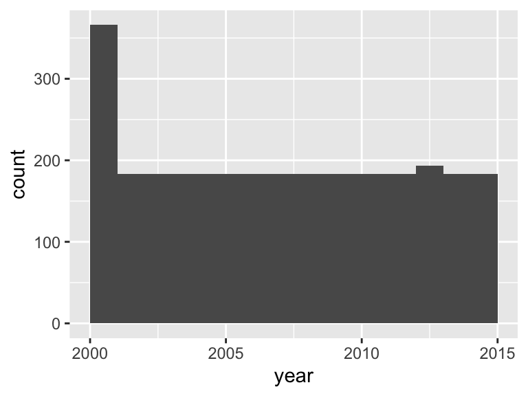

## status

| Feature | Result |
| --- | --- |
| Variable type | character |
| Number of missing obs. | 0 (0 %) |
| Number of unique values | 2 |
| Mode | “Developing” |

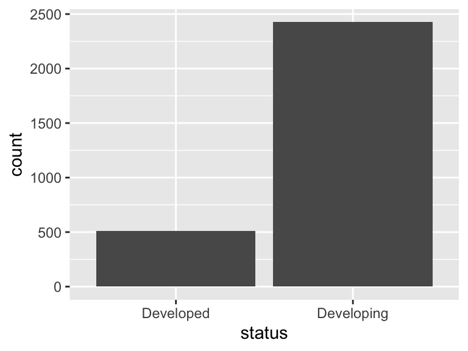

- Observed factor levels: "Developed", "Developing".

## life_expectancy

| Feature | Result |
| --- | --- |
| Variable type | numeric |
| Number of missing obs. | 10 (0.34 %) |
| Number of unique values | 362 |
| Median | 72.1 |
| 1st and 3rd quartiles | 63.1; 75.7 |
| Min. and max. | 36.3; 89 |

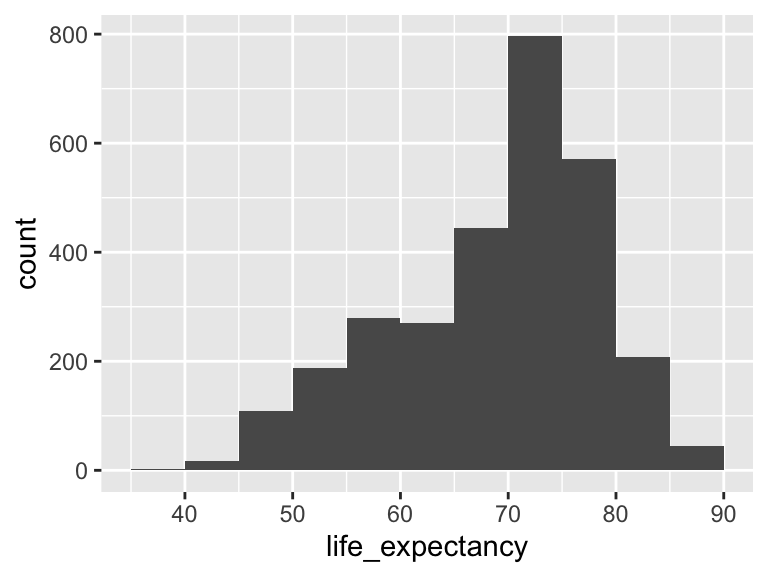

## adult_mortality

| Feature | Result |
| --- | --- |
| Variable type | numeric |
| Number of missing obs. | 10 (0.34 %) |
| Number of unique values | 425 |
| Median | 144 |
| 1st and 3rd quartiles | 74; 228 |
| Min. and max. | 1; 723 |

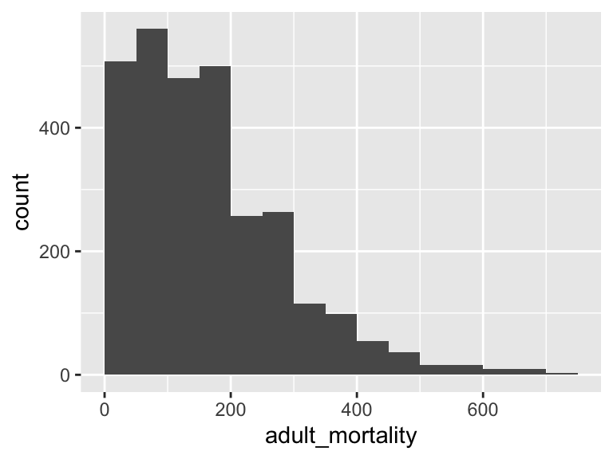

## infant_deaths

| Feature | Result |
| --- | --- |
| Variable type | numeric |
| Number of missing obs. | 848 (28.86 %) |
| Number of unique values | 208 |
| Median | 9 |
| 1st and 3rd quartiles | 2; 33 |
| Min. and max. | 1; 1800 |

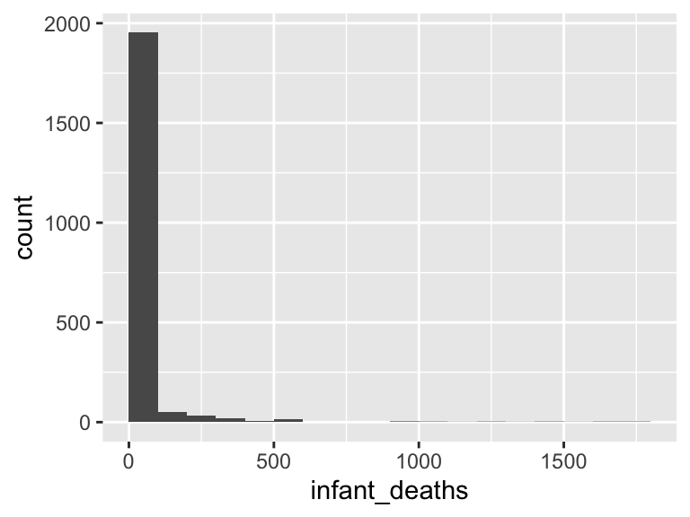

## alcohol

| Feature | Result |
| --- | --- |
| Variable type | numeric |
| Number of missing obs. | 194 (6.6 %) |
| Number of unique values | 1076 |
| Median | 3.75 |
| 1st and 3rd quartiles | 0.88; 7.7 |
| Min. and max. | 0.01; 17.87 |

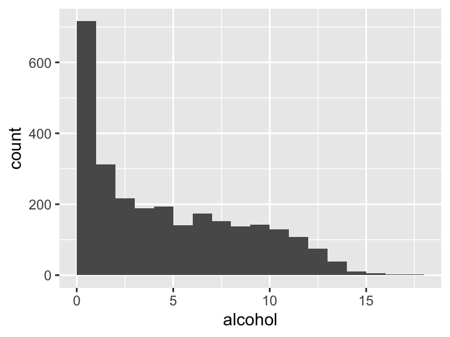

## percentage_expenditure

| Feature | Result |
| --- | --- |
| Variable type | numeric |
| Number of missing obs. | 611 (20.8 %) |
| Number of unique values | 2327 |
| Median | 155.2 |
| 1st and 3rd quartiles | 36.25; 630.22 |
| Min. and max. | 0.1; 19479.91 |

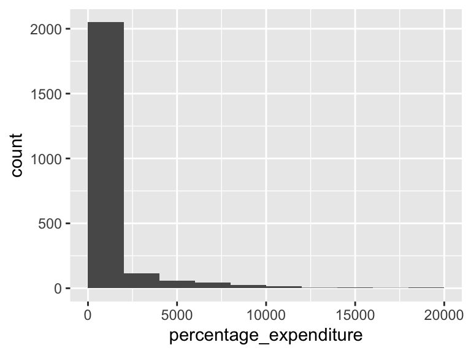

## hepatitis_b

| Feature | Result |
| --- | --- |
| Variable type | numeric |
| Number of missing obs. | 553 (18.82 %) |
| Number of unique values | 87 |
| Median | 92 |
| 1st and 3rd quartiles | 77; 97 |
| Min. and max. | 1; 99 |

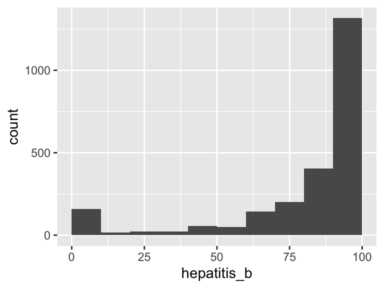

## measles

| Feature | Result |
| --- | --- |
| Variable type | numeric |
| Number of missing obs. | 0 (0 %) |
| Number of unique values | 958 |
| Median | 17 |
| 1st and 3rd quartiles | 0; 360.25 |
| Min. and max. | 0; 212183 |

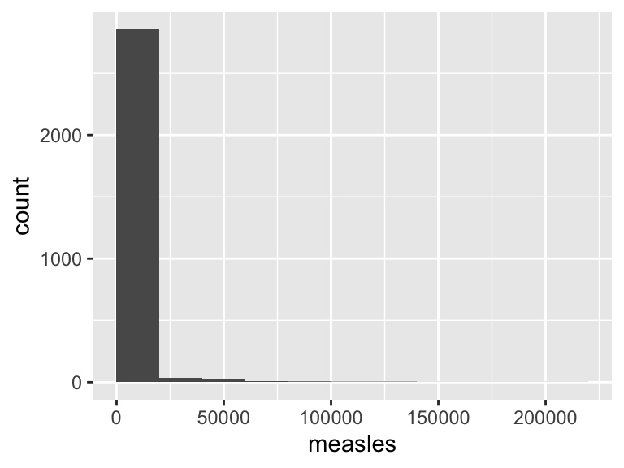

## bmi

| Feature | Result |
| --- | --- |
| Variable type | numeric |
| Number of missing obs. | 34 (1.16 %) |
| Number of unique values | 608 |
| Median | 43.5 |
| 1st and 3rd quartiles | 19.3; 56.2 |
| Min. and max. | 1; 87.3 |

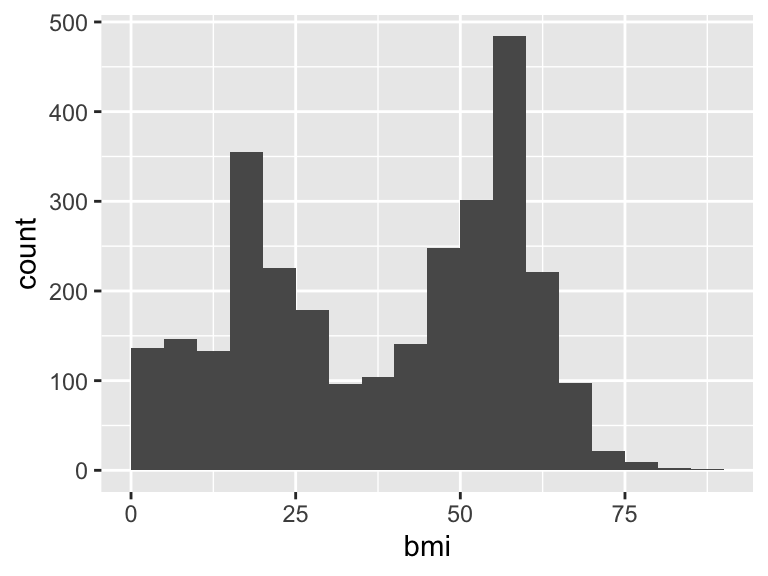

## under_five_deaths

| Feature | Result |
| --- | --- |
| Variable type | numeric |
| Number of missing obs. | 0 (0 %) |
| Number of unique values | 252 |
| Median | 4 |
| 1st and 3rd quartiles | 0; 28 |
| Min. and max. | 0; 2500 |

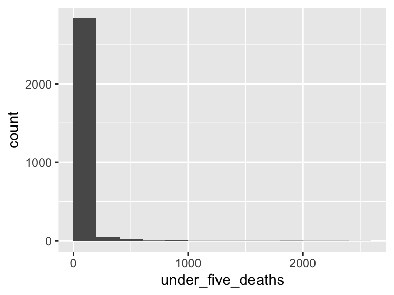

## polio

| Feature | Result |
| --- | --- |
| Variable type | numeric |
| Number of missing obs. | 19 (0.65 %) |
| Number of unique values | 73 |
| Median | 93 |
| 1st and 3rd quartiles | 78; 97 |
| Min. and max. | 3; 99 |

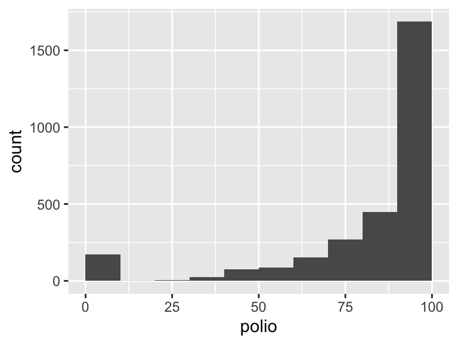

## total_expenditure

| Feature | Result |
| --- | --- |
| Variable type | numeric |
| Number of missing obs. | 226 (7.69 %) |
| Number of unique values | 818 |
| Median | 5.75 |
| 1st and 3rd quartiles | 4.26; 7.49 |
| Min. and max. | 0.37; 17.6 |

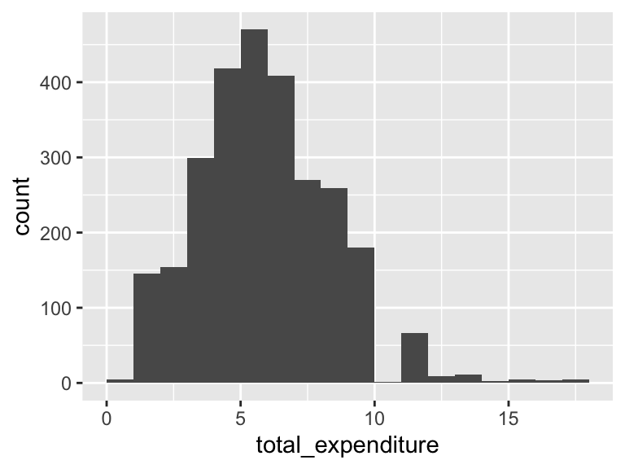

## diphtheria

| Feature | Result |
| --- | --- |
| Variable type | numeric |
| Number of missing obs. | 19 (0.65 %) |
| Number of unique values | 81 |
| Median | 93 |
| 1st and 3rd quartiles | 78; 97 |
| Min. and max. | 2; 99 |

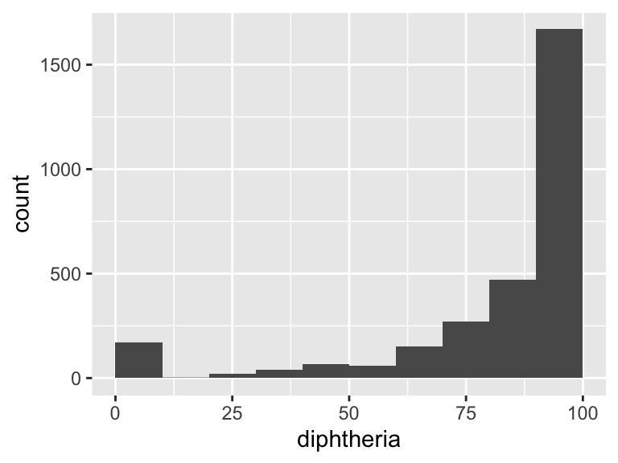

## hiv_aids

| Feature | Result |
| --- | --- |
| Variable type | numeric |
| Number of missing obs. | 0 (0 %) |
| Number of unique values | 200 |
| Median | 0.1 |
| 1st and 3rd quartiles | 0.1; 0.8 |
| Min. and max. | 0.1; 50.6 |

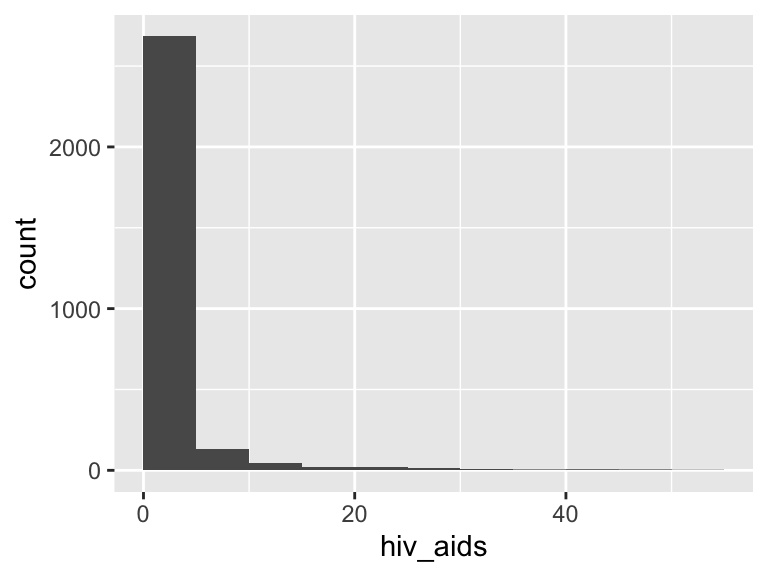

## gdp

| Feature | Result |
| --- | --- |
| Variable type | numeric |
| Number of missing obs. | 448 (15.25 %) |
| Number of unique values | 2490 |
| Median | 1766.95 |
| 1st and 3rd quartiles | 463.94; 5910.81 |
| Min. and max. | 1.68; 119172.74 |

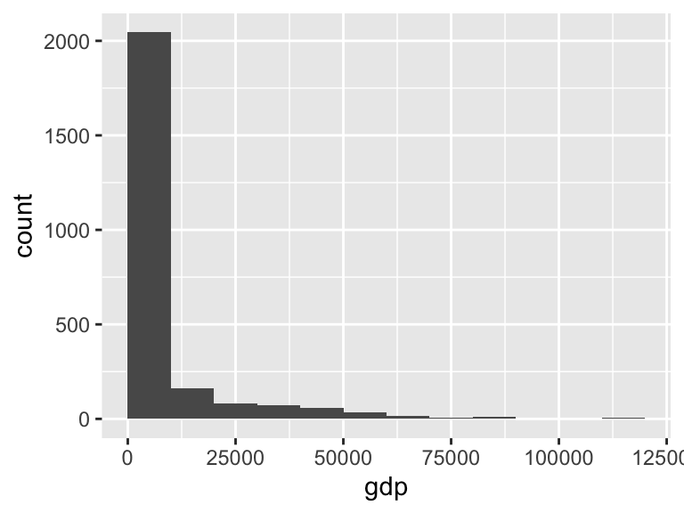

## population

| Feature | Result |
| --- | --- |
| Variable type | numeric |
| Number of missing obs. | 683 (23.25 %) |
| Number of unique values | 2251 |
| Median | 1435568 |
| 1st and 3rd quartiles | 228204.5; 7494541.5 |
| Min. and max. | 1141; 1293859294 |

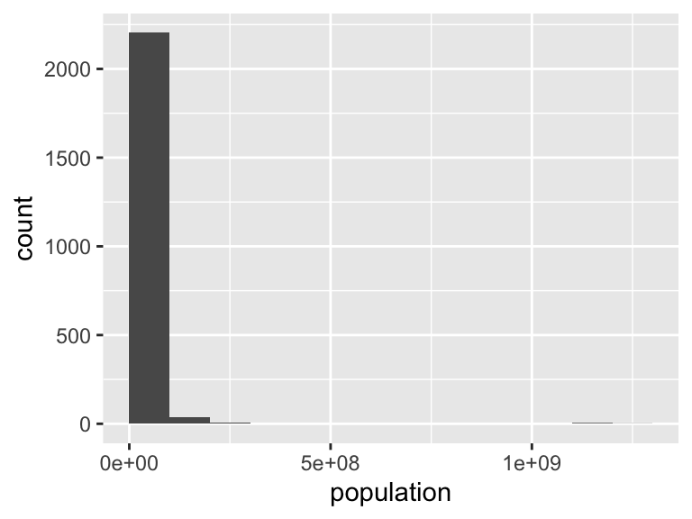

## thinness_10_to_19_years

| Feature | Result |
| --- | --- |
| Variable type | numeric |
| Number of missing obs. | 34 (1.16 %) |
| Number of unique values | 200 |
| Median | 3.3 |
| 1st and 3rd quartiles | 1.6; 7.2 |
| Min. and max. | 0.1; 27.7 |

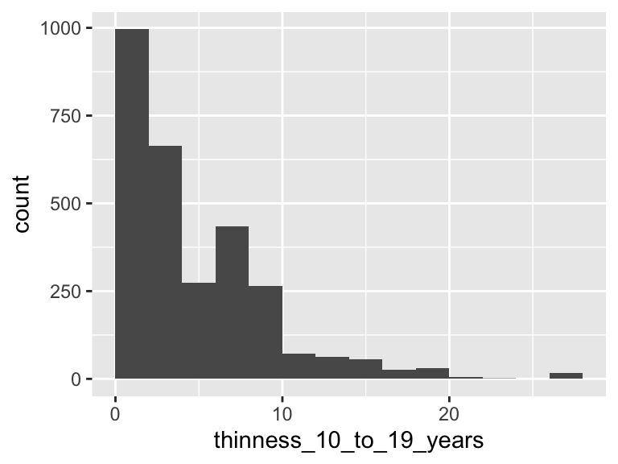

## thinness_5_to_9_years

| Feature | Result |
| --- | --- |
| Variable type | numeric |
| Number of missing obs. | 34 (1.16 %) |
| Number of unique values | 207 |
| Median | 3.3 |
| 1st and 3rd quartiles | 1.5; 7.2 |
| Min. and max. | 0.1; 28.6 |

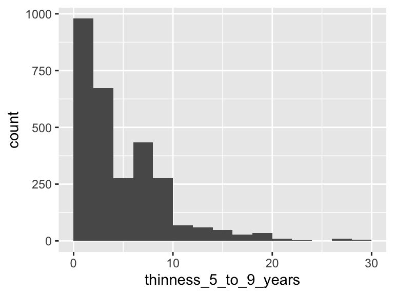

## income_composition_of_resources

| Feature | Result |
| --- | --- |
| Variable type | numeric |
| Number of missing obs. | 167 (5.68 %) |
| Number of unique values | 625 |
| Median | 0.68 |
| 1st and 3rd quartiles | 0.49; 0.78 |
| Min. and max. | 0; 0.95 |

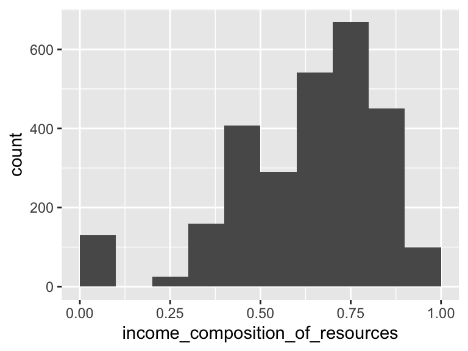

## schooling

| Feature | Result |
| --- | --- |
| Variable type | numeric |
| Number of missing obs. | 163 (5.55 %) |
| Number of unique values | 173 |
| Median | 12.3 |
| 1st and 3rd quartiles | 10.1; 14.3 |
| Min. and max. | 0; 20.7 |

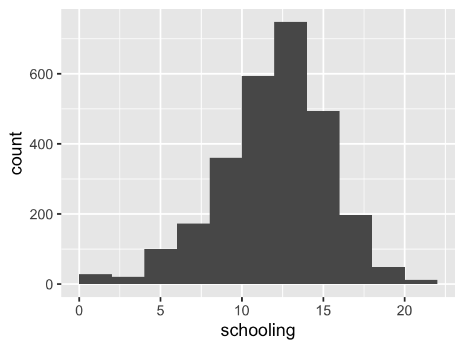

Report generation information:

- Created by Gillian Haggerty (username: `gillianhaggerty`).
- Report creation time: Sun Dec 08 2019 12:07:51
- Report was run from directory: `/Users/gillianhaggerty/Dropbox/Gillian/School/Northwestern/Stat 301-1/Final Project`
- dataMaid v1.3.2 [Pkg: 2019-07-27 from CRAN (R 3.6.0)]
- R version 3.6.1 (2019-07-05).
- Platform: x86_64-apple-darwin15.6.0 (64-bit)(macOS Mojave 10.14.6).
- Function call: `makeDataReport(data = LED_clean, mode = c("summarize", "visualize", "check"), smartNum = FALSE, file = "codebook_LED_clean.Rmd", replace = TRUE, checks = list(character = "showAllFactorLevels", factor = "showAllFactorLevels", labelled = "showAllFactorLevels", haven_labelled = "showAllFactorLevels", numeric = NULL, integer = NULL, logical = NULL, Date = NULL), listChecks = FALSE, maxProbVals = Inf, codebook = TRUE, reportTitle = "Codebook for LED_clean")`